# Team CarJan: Predict tree cover

Jan Droesen and Careli Caballero

January 14, 2016

In this report a model is developed for predicting the percentage of tree cover at the Gewata dataset.

## Processing data and plot bands against tree cover

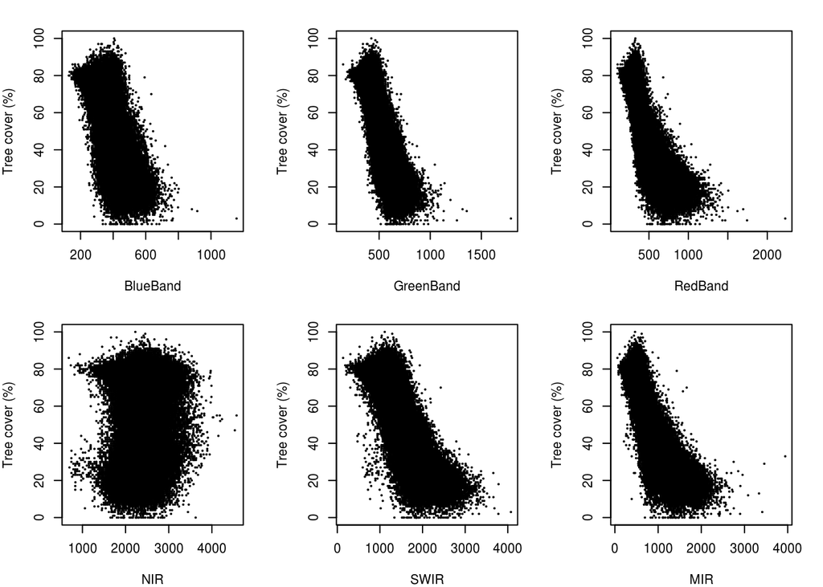

```r
#Erase tree cover higher than 100%
vcfGewata[vcfGewata > 100] <- NA

#make bricks and assign names to each brick layer
bandsgewata <- brick(GewataB1,GewataB2, GewataB3, GewataB4, GewataB5, GewataB7)
alllayers <- addLayer(bandsgewata, vcfGewata)
names(bandsgewata) <- c("BlueBand", "GreenBand", "RedBand", "NIR", "SWIR", "MIR")
names(alllayers) <- c("BlueBand", "GreenBand", "RedBand", "NIR", "SWIR", "MIR", "VCF")

#plot all bands with VCF
par(mfrow = c(3,2))
plot(alllayers[[1:6]], alllayers[[7]], xlab = names(alllayers), ylab = ("Tree cover (%)"))
```

Each plot represents the relation between LANDSAT7 ETM+ bands and the Vegetation Continuous Field product. High correlations for the red and SWIR can be derived.

```r
#process data for linear regression model
dfgewata <- as.data.frame(getValues(alllayers))
#erase NAś
dfgewata <- na.omit(dfgewata)

#multiple regression model with all bands
modelMultipleAll <- lm(VCF ~ BlueBand + GreenBand + RedBand + NIR + SWIR + MIR, data = dfgewata)
#check for significant bands
summary(modelMultipleAll)
```

```
##
## Call:
## lm(formula = VCF ~ BlueBand + GreenBand + RedBand + NIR + SWIR +
##     MIR, data = dfgewata)
##
## Residuals:
##     Min      1Q  Median      3Q     Max
## -58.205  -4.636   0.715   5.211 258.436
##
## Coefficients:
##               Estimate Std. Error  t value Pr(>|t|)
## (Intercept)  8.549e+01  5.723e-02 1493.805   <2e-16 ***
## BlueBand     9.291e-02  1.889e-04  491.817   <2e-16 ***
## GreenBand   -1.505e-01  2.353e-04 -639.622   <2e-16 ***
## RedBand     -2.528e-03  1.698e-04  -14.889   <2e-16 ***
## NIR          1.661e-02  2.790e-05  595.378   <2e-16 ***
## SWIR        -2.006e-02  7.036e-05 -285.119   <2e-16 ***
## MIR          2.549e-05  8.969e-05    0.284    0.776
## ---
## Signif. codes:  0 '***' 0.001 '**' 0.01 '*' 0.05 '.' 0.1 ' ' 1
##
## Residual standard error: 8.606 on 1808277 degrees of freedom
## Multiple R-squared:  0.8582, Adjusted R-squared:  0.8582
## F-statistic: 1.824e+06 on 6 and 1808277 DF,  p-value: < 2.2e-16
```

```r
#erase non-significant band(s) and run linear regression model
modelMultiple <- lm(VCF ~ BlueBand + GreenBand + RedBand + NIR + SWIR, data = dfgewata)
```

From the multiple regression model of all bands the signifance is investigated. Non-significant bands (i.e. only the Middle Infrared (MIR) band) were erased. The optimal multiple regression model is now calculated.

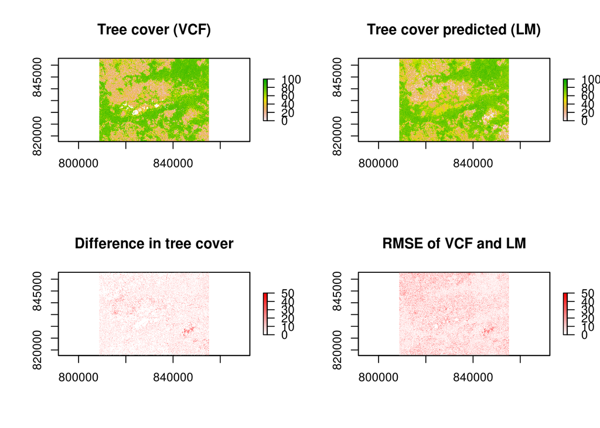

```r
#predicted values
predTC <- predict(bandsgewata, model=modelMultiple, na.rm=TRUE)

#comparing predicted and VCF tree cover

#get the difference between VCF and predicted
raserDif <- vcfGewata - predTC

#calculate RMSE separately for each of the classes
calcRMSE <- function(x,y){
    sqrt(mean((x-y)^2))
}
polyError <- calcRMSE(vcfGewata,predTC)

#visualize difference beteen VCF and predicted
colfunc <- colorRampPalette(c("white", "red"))
par(mfrow = c(2,2))
plot(vcfGewata, main="Tree cover (VCF)", zlim=c(0,100) )
plot(predTC, main="Tree cover predicted (LM)", zlim=c(0,100)) #add 0-100
plot(raserDif, main="Difference in tree cover", col=colfunc(255),  zlim=c(0,50))
plot(polyError, main="RMSE of VCF and LM",col=colfunc(255),  zlim=c(0,50))
```

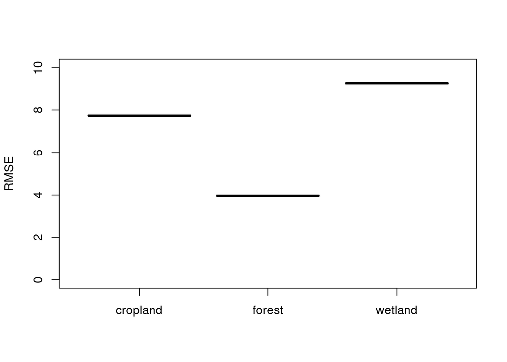

```r
#get errors for the LM with the land cover types
load("data/trainingPoly.rda")
trainingPoly@data$Code <- as.numeric(trainingPoly@data$Class)
classes <- rasterize(trainingPoly, polyError, field='Code')

#calculate error per land cover class
errorTraining <- zonal(polyError, classes, fun='mean', digits=0)
dferrorTraining <- as.data.frame(errorTraining)

#which class corresponds to highest error
mergedPolyError <- merge(x = trainingPoly, y = dferrorTraining, by.x = "Code", by.y = "zone")

#visualize errors per land cover type
x <- mergedPolyError$Class
y <- mergedPolyError$mean
par(mfrow=c(1,1))
plot(x,y, ylim= c(0,10), "s", ylab="RMSE")
```

After getting the error per each land cover class (cropland, forest and wetland), the most accurate class was forest with the lowest error, which was as expected, because of the VCF product.